# Course workbook

## 1 Using RStudio

## Getting Started with RStudio

When you first load up RStudio you will probably get something as follows:

[figure not shown]

Illustration of Rstudio and its four panes. Top left: Script pane; Bottom left: I/O pane; Bottom right: figures, help and documentation; Top right: history and environment

RStudio basically divides the display into four panes. With the exception of the bottom left pane, each pane contains a number of tabs, allowing you to switch between the types of information displayed. The relative size of each pane can be adjusted, and you can minimise and maximise each pane too. The contents and purpose of each of the four panes is as follows:

## RStudio Features

**Exercise**: Go into the ‘global options’ line within the ‘Tools’ dropdown menu within RStudio, then select ‘Appearance’, then the ‘Idle Fingers’ editor theme. The colour coding described below uses this theme, but the principle is broader. If you prefer, select a different theme, or use the default theme.

RStudio offers a number of subtle but important features compared with accessing R through its native GUI. In particular, the features available in the script window offer a number of important advantages over writing the scripts in a simple text editor like notepad or the script editor included with R. To start to learn both about some of these features, and about R as a programming language, let’s look at the following figure:

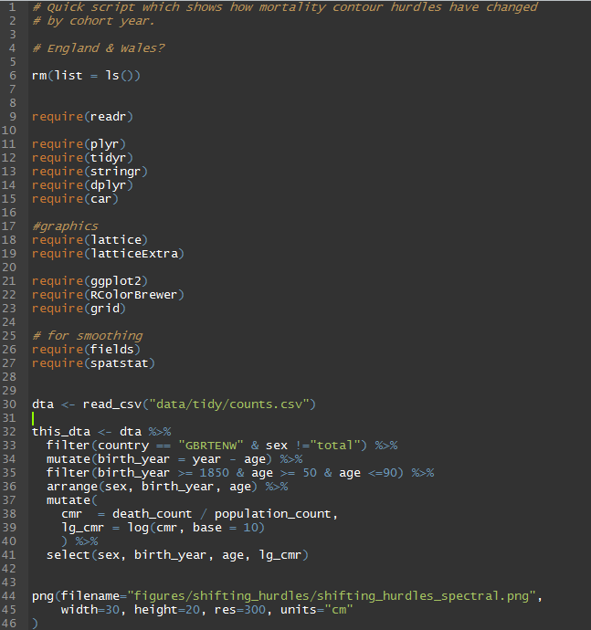

Example of an R script in the RStudio console

One of the first things to note is that different parts of the text are coloured in different ways. These colours aren’t put in manually by the user, by generated automatically by RStudio, as it recognises different parts of the text as specifying different types of information for the R Console. Some examples:

- **Light orange** (lines 1, 2, 4, 17, 25): These are comments, which R ignores, and written by the user to help them and other users understand the code better. Comments are distinguished from commands with the # (hash) symbol. The R console knows to ignore any text to the right of this symbols. (This means you can put a comment on the same line as an instruction, with the instruction on the left, the comment on the right, and the # symbol separating the two.)
- **Dark orange** (most lines 9-27): These are some of the functions contained in ‘Base R’, the functions that are an integral part of the R language. The function shown here is the ‘require’ function, which loads R packages, containing additional functions, into the current R environment.
- **Green** (lines 30 onwards): These are ‘string’ objects. Strings are technically vectors of character objects, but more intuitively ‘chunks’ of text. The distinction between string and other objects is subtle but important.
- **Blue** (throughout): These include symbols like parentheses (), the assignment operator <-, the pipe operator %>%, and simple (‘unpaired’) values (10, 50, 90, etc). Apart from the simple values, these symbols can be best thought of as being like conjunctions (‘and’, ‘with’, ‘and then’ etc) in sentences, with the roles of joining and connecting statements together.
- **White** (throughout): These pieces of the text are objects and non-base functions. They are the equivalent to nouns and verbs in sentences: ‘things’ and ‘stuff that gets done to things’. Just as in English, where nouns can get turned to verbs (e.g. ‘crawfished’, to use a Bushism), and verbs can get turned into nouns (e.g. ‘decide’ to ‘decision’), there’s a similar kind of mutability in the R language, hence the same colour being applied to both parts of the text.

**Exercise**: Create an R script and write out some of the lines in the script above, noting how different parts of the code are highlighted in different ways. If a different colour scheme has been used, work out which text colours indicate which parts of the code. (objects, operators, strings, comments, and so on.) Alternatively, look through the code snippet example presented in Tools -> Options -> Appearance -> Editor theme, and how this changes when different themes are selected.

## Autocomplete features

Most of the features in the script pane are only apparent when writing in the pane. For example, if you type

rm(

Into the script, RStudio automatically adds a right parentheses

rm()

Because it knows that this particular piece of text refers to a function rather than an object, and functions need to have an open parentheses ‘(‘at the start and a closed parentheses‘)’ at the end. If your cursor (indicated with a vertical line ‘|’ ) is located in the middle of this function, immediately after the left parentheses, and you press the tab button, the following drop-down list opens up

[figure not shown]

The purple items in the list are known as the **arguments** to the function, which modify the function’s behaviour. The yellow items in the list are objects found in the current R environment. These are things that you might want to pass to the function.

You can also see the yellow box to the right of the drop down list. This contains extra information on the particular highlighted item.

**Exercise**: Reproduce the in-text drop-down list shown above.

Another useful feature is name autocomplete. For example I can create an object, with a very long name, containing a value, as follows:

this_is_a_very_long_name_that_i_have_decided_to_use_because_i_really_like_typing_for_the_sake_of_it <- 2

Here I have created an object with a very long name, which just contains (has been assigned, using the assignment operator <- ) the value 2. After creating this object, I can type the first bit of the name, then press ‘tab’, and I get a drop-down menu:

[figure not shown]

Rstudio knows that there are two possible objects in the workspace that I might be referring to, this_data and the object with the very long name I’ve just created. I can use the arrow keys to select between these objects, then press tab, and the rest of the object name is automatically filled in. This little feature can be very important for two reasons: firstly it allows you to use long object names, which can be more helpful for helping to describe the code, without being penalised as much in terms of time spent typing. Secondly, it greatly reduces the risk of typos. If you mis-type something in R, it will think you are referring to a completely different object, either creating an object by accident (leading to errors occurring later in the code), or not finding the object you are referring to (leading to an error at this point in the code).

**Exercise**: Produce two objects, one with a long name, the other with a short name, and whose names both start with the same characters, and use the drop-down menu to choose between them. Assign the value of one of the objects to the other object, and delete one or both objects.

## 2 Manipulating data

In this section we will look at manipulating data with the dplyr package. dplyr is designed to simplify and standardise data manipulation in R. It has grown out of extensive research into how people actually manipulate data.

Even very experienced R users, and I started using R in 2008, have moved over to dplyr for its several advantages; it is incredibly fast, consistent and easy to use. One of the consistencies is brought about by the use of tibbles. tibbles are essentially dataframes with stricter rules about converting between types of objects, and better default printing options.

We will work through a typical ISD problem using dplyr consulting the RStudio cheatsheet on “Data Transformation with dplyr” (https://www.rstudio.com/resources/cheatsheets/). Before that, it is important to cover a few key concepts.

### 1. dplyr works at the dataframe (not the vector) level.

This might seem like a move back to SPSS-type approaches, and in some ways it is. dplyr gives the advantages of a very simple interface for much data manipulation work, but with modern consitent approaches and a tight integration with R’s wider functionality.

### 2. Each data manipultion action is represented as a dplyr function.

```r
filter() (and slice()) # choose rows
arrange() # order rows
select() (and rename()) # choose/rename columns
distinct() # select distinct rows
mutate() (and transmute()) # add columns (without/with dropping existing columns)
summarise() # summarise results using some aggregating function
sample_n() (and sample_frac()) # take a random sample of a dataframe
```

### 3. Chaining

Which of these three versions of code is easier to follow:-

Intermediate step code

```r
a1 <- group_by(flights, year, month, day)
a2 <- select(a1, arr_delay, dep_delay)
a3 <- summarise(a2,
  arr = mean(arr_delay, na.rm = TRUE),
  dep = mean(dep_delay, na.rm = TRUE))
a4 <- filter(a3, arr > 30 | dep > 30)
```

Nested function code

```r
filter(
  summarise(
    select(
      group_by(flights, year, month, day),
      arr_delay, dep_delay
    ),
    arr = mean(arr_delay, na.rm = TRUE),
    dep = mean(dep_delay, na.rm = TRUE)
  ),
  arr > 30 | dep > 30
)
```

Chained function code

```r
flights %>%
  group_by(year, month, day) %>%
  select(arr_delay, dep_delay) %>%
  summarise(
    arr = mean(arr_delay, na.rm = TRUE),
    dep = mean(dep_delay, na.rm = TRUE)
  ) %>%
  filter(arr > 30 | dep > 30)
```

The latter uses pipes **%>%**. Pipes allow you some of the advantages of a step-by-step type interface such as is used in SPSS within an object-based language like R. The pipe is an “infix” function It is therefore of the form `a` *function* `b` (examples of infix functions are +, -, / *, ^). The pipe takes whatever object came before it and “pipes” it to the first slot of the function coming afterwards. In other words, the following are equivalent.

```r
f(x, y)
x %>% f(y)
```

One last thing about dplyr. It uses non-standard evaluation. Most R functions require the $ operator to use vectors within dataframes (eg `mean(mydf$x)`). dplyr uses non-standard evaluation (NSE), which avoids this. NSE reduces typing; but also allows dplyr code to be automatically translated into SQL. This means that dplyr code can be used to query databases such as the data warehouse at ISD. Special forms of the dplyr functions exist for use with user-defined functions.

## The problem

You have received an urgent information request. Some people are concerned that some environmental exposure in Lothian is increasing the rate of childhood Leukaemia. You have been asked to respond; specifically you have to:-

1. Calculate the number and rate of childhood leukaemia in Lothian and other health Boards
2. Summarise this graphically and in tables, and compare the Lothian rates to other regions in Scotland.

Open up the script. Childhood Leukaemia, and work through the exercises below.

**Exercise**: See script leukaemia.R

1. Load the data. Examine each table to understand the structure.
2. Run each section of code. Make sure you understand the pipe operator **%>%** and what each line of code is doing.
3. Modify the first section of code so that only codes in positions 1 or 2 are included.
4. Modify the code so that only first episodes are included.
5. Why did I use the dplyr if_else() function rather than the base R ifelse() function?
6. Exclude Fife data from the Rest of Scotland versus Lothian comparison
7. Count the total number of deaths within 30 days of discharge following an incident admission with leukaemia and calculate the 30-day case fatality proportion. Then aggregate this by health board and sex

# Messy data and tidy data with Tidyr

**Exercise**: see script waiting times.R

1. Run the code. Make sure that you have an idea of what each line does by running it.
2. In what ways are this data messy?
3. Why is it important to move rownames to the datafraem itself?
4. Pick a version of your team’s datasets that is not tidy. Consider how you would make it tidy.

# Data visualisation

## Data Visualisation using ggplot2

ggplot2 is Hadley Wickham’s most popular R package. It is designed for data visualisation. In ggplot2 the + operator behaves somewhat like the %>% operator does within dplyr and tidyr. However, order is irrelevant for ggplot2. Also, ggplot2 draws from a different paradigm, a way of thinking about and being explicit about the production of data graphics known as the ‘grammar of graphics’, based on a book of this name by the statistician Leland Wilkinson. A large number of introductions exist to ggplot2, but at its core the grammar of graphics approach is about providing a language for clearly defining *the mapping rules which link values in columns in a data frame to features on a graphical display*. Conceptually, this can be thought about as kind of ‘box wiring’ exercise, with data frame columns at one side of the box, and graphical features on the other end of the box. An example of this is shown below:

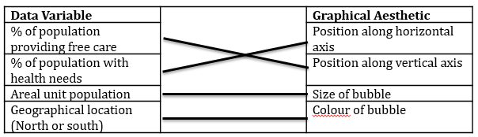

In this example the data frame, on the left, can be thought to contain four columns, and the values in each of these columns are ‘wired’ to so they control a different part of the graphic displayed. At a minimum, within ggplot2 the user needs to specify:

- The dataset which contains the variables
- The mapping rules, known as *aes*thetics, which define how the values of the variables control different parts of the graphic
- The *geom*etrics: the type of graphic element that is displayed

An illustration of how the above set of mapping rules may look within ggplot2 is as follows:

```r
ggplot2(dta, aes(x = health_care_records,y = health_care_provision, size = population_size, fill = is_north)) +
  geom_point()
```

The above example is based on the main figure in a 2004 paper by Mary Shaw and Danny Dorling[^1], reproduced below, along with the notes presented below that figure:

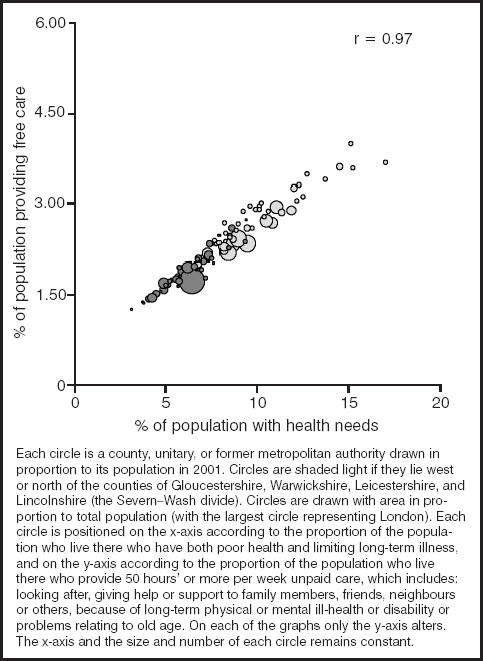

This figure was very likely produced in Excel. The grammar of graphics paradigm is largely independent of any particular statistical package or programming language, even though the ggplot2 package is specific to R.

**ggplot2: Cheat Sheet, Websites and Books**

For ggplot2, the standard R help files are often less useful than for many other functions and packages, mainly because the concepts and ideas are so inherently visual, whereas the help files are text files. Instead the official website is generally a much more effective resource for learning about ggplot2 in action:

http://docs.ggplot2.org/0.9.3.1/index.html

**Exercise:** Explore and discuss the cheat sheet and website with other attendees.

As suggested by its smaller font size and increased number of columns, the data visualisation cheat sheet contains more content than the data wrangling cheat sheet, not least because ggplot2 is an older, better developed and more complex package than dplyr and tidyr, and so requires more knowledge and experience to use properly. An extremely good book for using ggplot2 is Hadley Wickham’s own ggplot2 book (second edition)

[^1]: Shaw M & Dorling D (2004) “Who cares in England and Wales? The Positive Care Law: cross-sectional study” *British Journal of General Practice*, 54 (509): 899-903